# Occupational Prestige: A Reproducible Report

Author

Julio Iturra-Sanhueza

Published

May 20, 2026

Abstract

## 1 Introduction

This report analyses occupational prestige scores from the `Prestige` dataset (Duncan, 1961; `car` package). The dataset covers **102** occupations measured across Canada. The mean prestige score is **46.8** (SD = 17.2), with values ranging from 14.8 to 87.2.

We examine how income, education, gender composition, and occupational type predict prestige.

## 2 Data and Variables

### 2.1 Descriptive Statistics

Table 1 reports summary statistics for all processed variables.

Table 1: Descriptive statistics of processed variables

| Variable | N | Mean (%) | Median | SD | Min | Max |
| --- | --- | --- | --- | --- | --- | --- |
| education | 102 | 11 | 11 | 2.7 | 6.4 | 16 |
| income | 102 | 6798 | 5930 | 4246 | 611 | 25879 |
| women | 102 | 29 | 14 | 32 | 0 | 98 |
| prestige | 102 | 47 | 44 | 17 | 15 | 87 |
| census | 102 | 5402 | 5135 | 2645 | 1113 | 9517 |
| type | 98 |  |  |  |  |  |
| ... bc | 44 | 45% |  |  |  |  |
| ... prof | 31 | 32% |  |  |  |  |
| ... wc | 23 | 23% |  |  |  |  |
| prestige_cont | 102 | 47 | 44 | 17 | 15 | 87 |
| income_cont | 102 | 6798 | 5930 | 4246 | 611 | 25879 |
| education_cont | 102 | 11 | 11 | 2.7 | 6.4 | 16 |
| women_pct | 102 | 29 | 14 | 32 | 0 | 98 |
| income_cat | 102 |  |  |  |  |  |
| ... High | 11 | 11% |  |  |  |  |
| ... Low | 70 | 69% |  |  |  |  |
| ... Mid | 21 | 21% |  |  |  |  |
| education_level | 102 |  |  |  |  |  |
| ... High | 23 | 23% |  |  |  |  |
| ... Low | 48 | 47% |  |  |  |  |
| ... Mid | 31 | 30% |  |  |  |  |
| prestige_tier | 102 |  |  |  |  |  |
| ... High | 24 | 24% |  |  |  |  |
| ... Low | 20 | 20% |  |  |  |  |
| ... Mid | 58 | 57% |  |  |  |  |
| blue_collar | 102 |  |  |  |  |  |
| ... 0 | 58 | 57% |  |  |  |  |
| ... 1 | 44 | 43% |  |  |  |  |
| professional | 102 |  |  |  |  |  |
| ... 0 | 71 | 70% |  |  |  |  |
| ... 1 | 31 | 30% |  |  |  |  |
| high_women | 102 | 0.26 | 0 | 0.44 | 0 | 1 |

Note:  
Numeric variables: mean, median, SD, min, max. Categorical: counts and percentages.

## 3 Visualizations

### 3.1 Univariate Distributions

Figure 1 shows the distribution of prestige scores across occupations. The distribution is roughly symmetric with a slight right skew. Figure 2 displays the frequency of income categories.

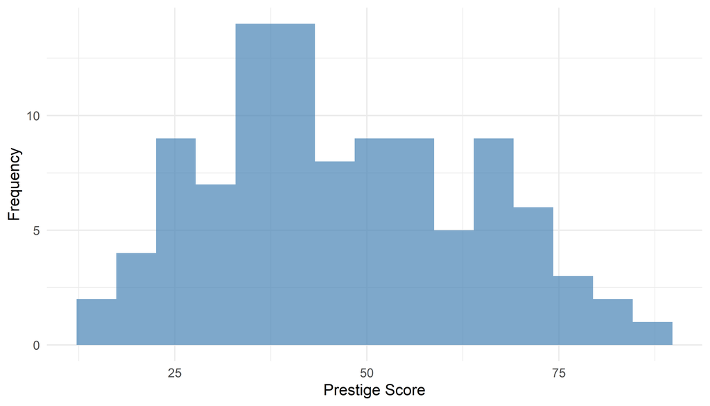

Figure 1: Distribution of occupational prestige scores

```r
p_hist <- ggplot(dfstudy1, aes(x = prestige_cont)) +
  geom_histogram(bins = 15, fill = "steelblue", alpha = 0.7) +
  labs(x = "Prestige Score", y = "Frequency") +
  theme_minimal()

ggsave(here("output/images/figure001.png"), p_hist, width = 7, height = 4, dpi = 300)
p_hist
```

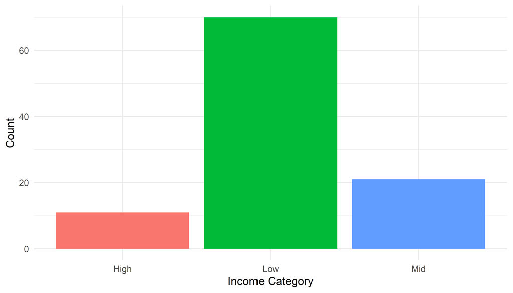

Figure 2: Frequency of income categories

```r
p_bar <- ggplot(dfstudy1, aes(x = income_cat, fill = income_cat)) +
  geom_bar(show.legend = FALSE) +
  labs(x = "Income Category", y = "Count") +
  theme_minimal()

ggsave(here("output/images/figure002.png"), p_bar, width = 7, height = 4, dpi = 300)
p_bar
```

### 3.2 Bivariate Relationships

Figure 3 presents the relationship between education and prestige, and Figure 4 shows the distribution of prestige across income categories. Both panels suggest that higher education and income are associated with greater occupational prestige.

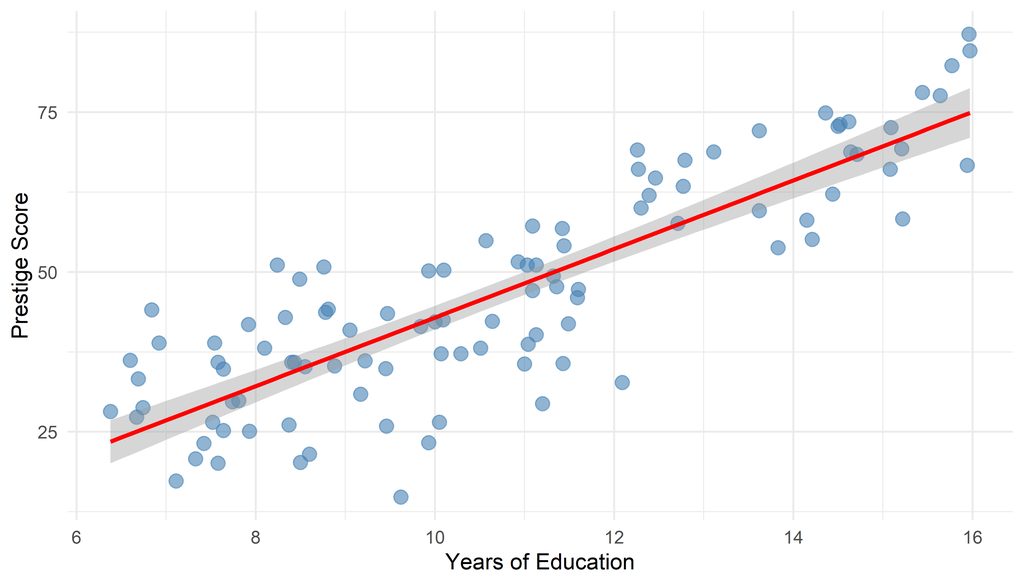

Figure 3: Prestige vs. years of education

```r
p_scatter <- ggplot(dfstudy1, aes(x = education_cont, y = prestige_cont)) +
  geom_point(alpha = 0.6, size = 3, color = "steelblue") +
  geom_smooth(method = "lm", se = TRUE, color = "red") +
  labs(x = "Years of Education", y = "Prestige Score") +
  theme_minimal()

ggsave(here("output/images/figure003.png"), p_scatter, width = 7, height = 5, dpi = 300)
p_scatter
```

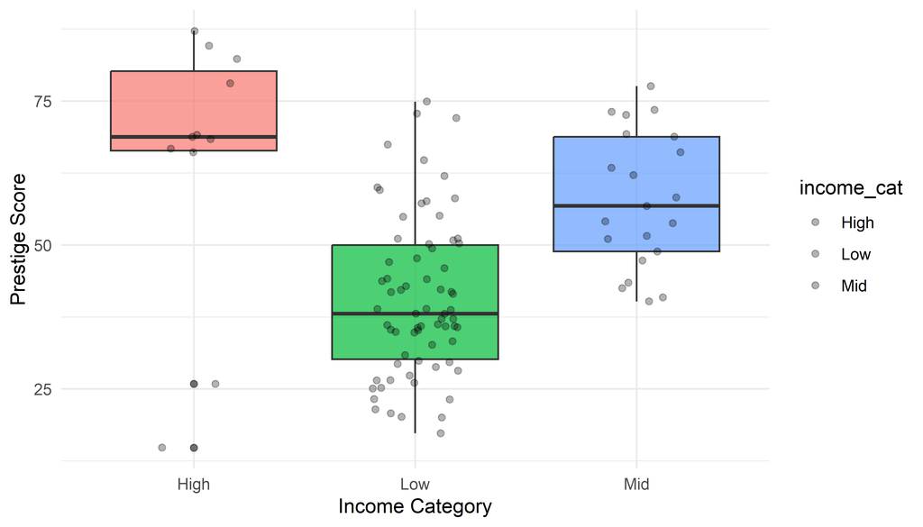

Figure 4: Prestige score by income category

```r
p_box <- ggplot(dfstudy1, aes(x = income_cat, y = prestige_cont, fill = income_cat)) +
  geom_boxplot(alpha = 0.7, show.legend = FALSE) +
  geom_jitter(width = 0.2, alpha = 0.3) +
  labs(x = "Income Category", y = "Prestige Score") +
  theme_minimal()

ggsave(here("output/images/figure004.png"), p_box, width = 7, height = 5, dpi = 300)
p_box
```

## 4 Regression Analysis

We estimate four OLS models predicting occupational prestige. Models 1 and 2 use continuous predictors; Models 3 and 4 use categorical versions. The full model (Model 4) explains **71.9%** of the variance in prestige and includes gender composition and blue-collar status as additional controls.

Results are reported in Table 2.

Table 2: OLS regression models predicting occupational prestige

Statistical models

|  | M1 Cont. | M2 Cont. | M3 Cat. | M4 Cat. |
| --- | --- | --- | --- | --- |
| Intercept | -6.85* | -11.05 | 32.95*** | 33.47*** |
|  | (3.22) | (6.19) | (1.41) | (3.17) |
| Income (continuous) | 0.00*** | 0.00*** |  |  |
|  | (0.00) | (0.00) |  |  |
| Education (continuous) | 4.14*** | 4.49*** |  |  |
|  | (0.35) | (0.55) |  |  |
| Income: Mid (ref. Low) |  |  | 5.44* | 3.81 |
|  |  |  | (2.59) | (2.72) |
| Income: High (ref. Low) |  |  | 8.79* | 7.44* |
|  |  |  | (3.40) | (3.59) |
| Education: Mid (ref. Low) |  |  | 15.33*** | 16.72*** |
|  |  |  | (2.20) | (3.04) |
| Education: High (ref. Low) |  |  | 31.75*** | 33.25*** |
|  |  |  | (2.79) | (3.64) |
| Women (%) |  | -0.00 |  |  |
|  |  | (0.03) |  |  |
| High women share: Yes (ref. No) |  |  |  | -4.12 |
|  |  |  |  | (2.37) |
| Blue collar: Yes (ref. No) |  | 2.11 |  | 0.67 |
|  |  | (2.61) |  | (3.12) |
| R<sup>2</sup> | 0.80 | 0.80 | 0.71 | 0.72 |
| Adj. R<sup>2</sup> | 0.79 | 0.79 | 0.70 | 0.70 |
| Num. obs. | 102 | 102 | 102 | 102 |

***p < 0.001; **p < 0.01; *p < 0.05